# Project: Investigating TMBD dataset

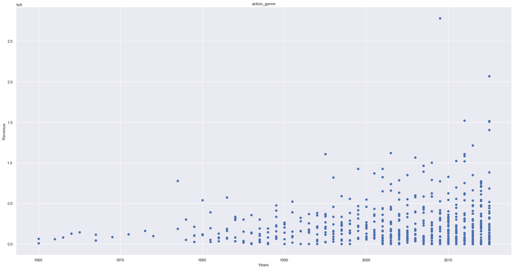

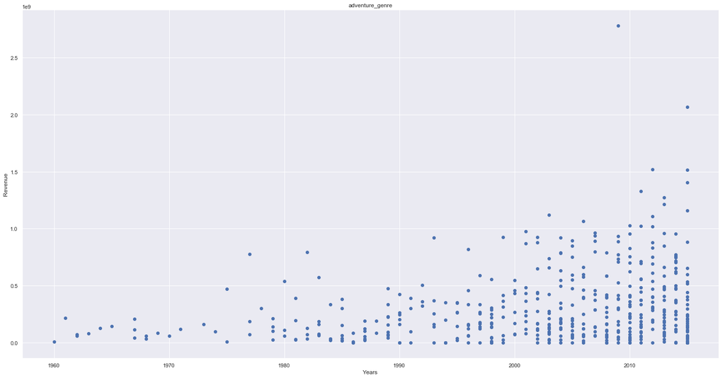

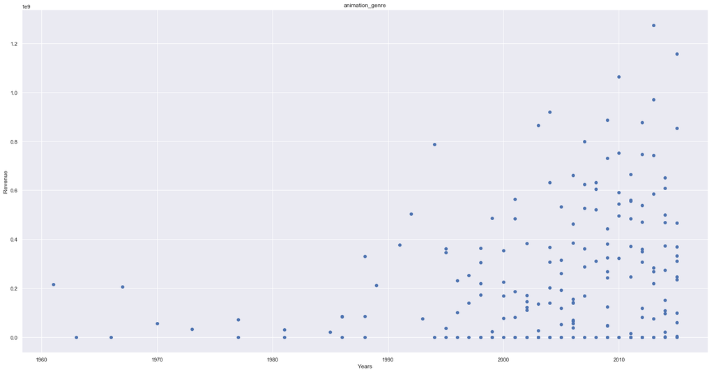

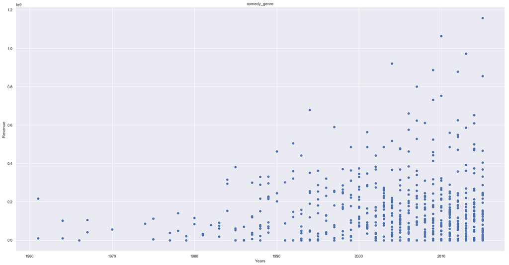

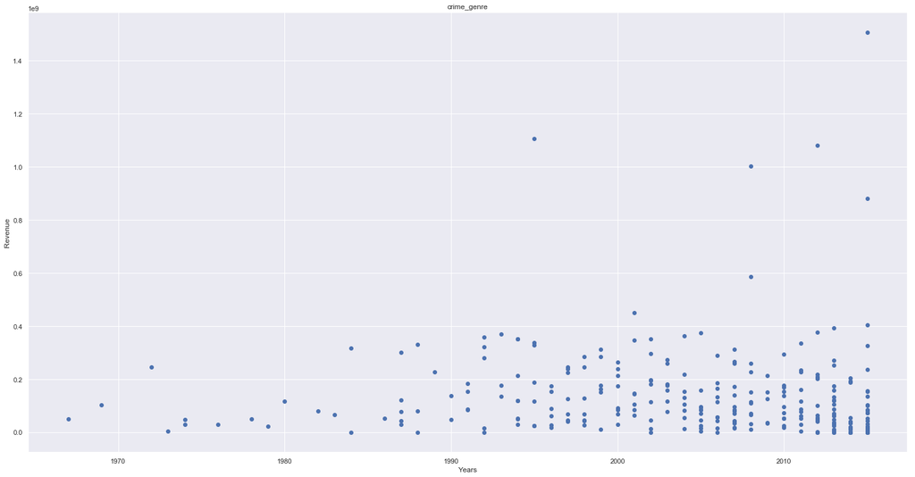

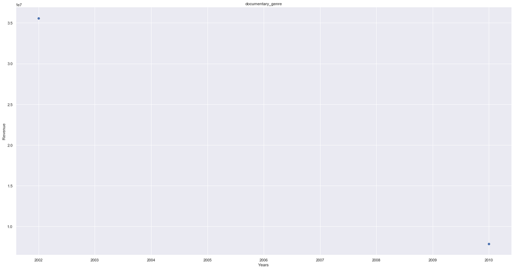

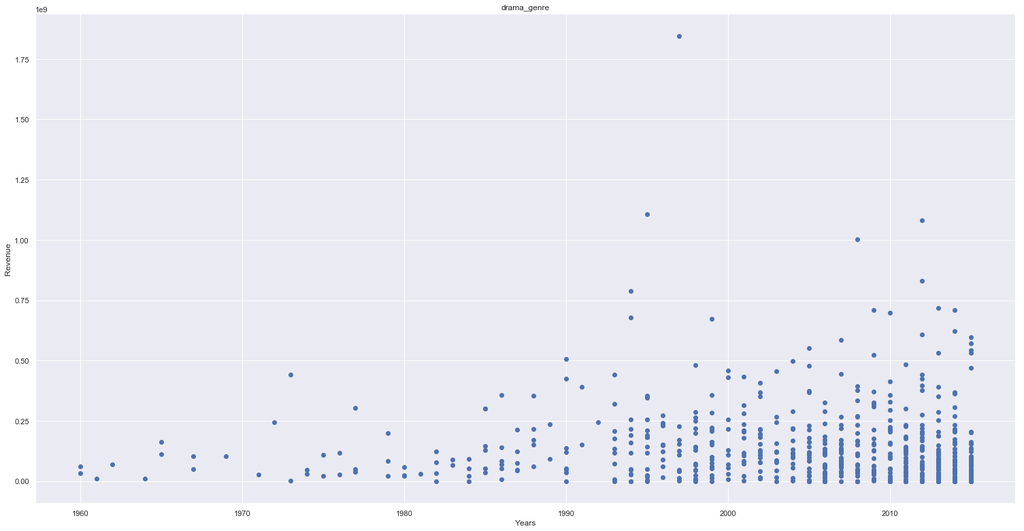

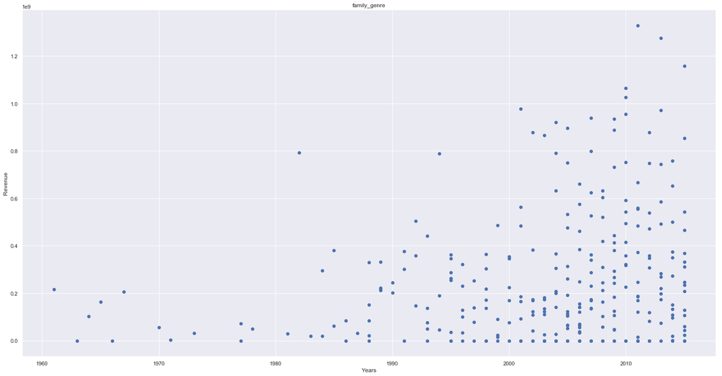

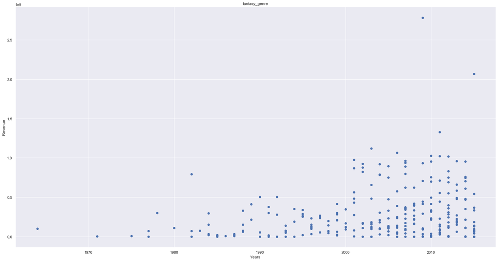

[figure not shown]

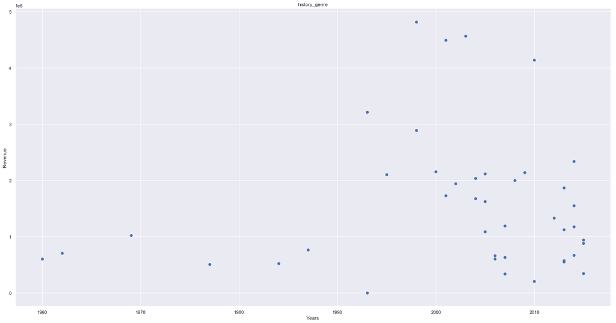

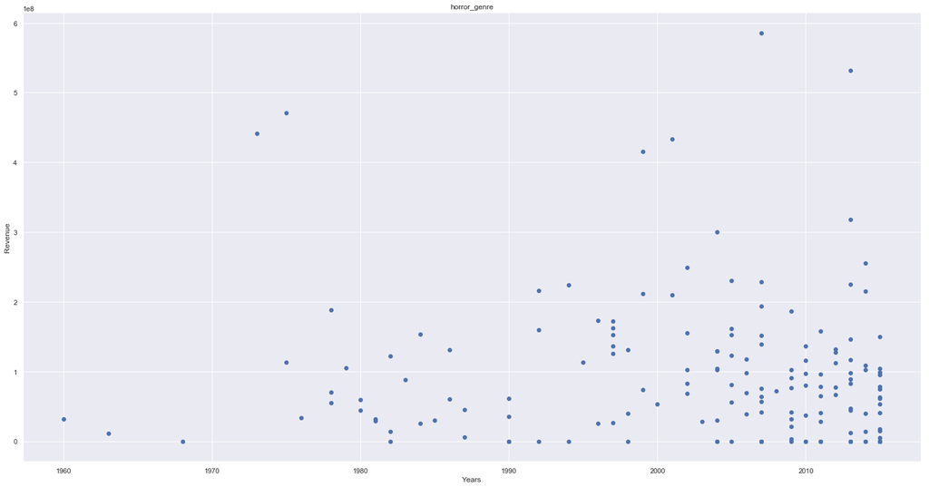

[8 more figures not shown]

```python
np.random.seed(0)
for genre in genresDictionary:
    fig=plt.figure(figsize=(20,10))
    ax=fig.add_axes([0,0,1,1])
    revenue = genresDictionary[genre].revenue
    time_range = genresDictionary[genre].release_year

    ax.scatter(time_range, revenue,label=genre)
    ax.set_xlabel('Years')
    ax.set_ylabel('Revenue')
    ax.set_title('scatter plot')
    plt.title(genre)
    plt.show()
```

**The following charts are meant to provide an understanding on how much each genre has as share in the respective realm**

This one for example shows documentary to the real lowest in terms of revenue, this is likely because no one watches a documentary in theatre.  
Horror on average also has very little revenue, likely by the fact that it is R rated usually, and that most horror movies low budget generally terrible movies

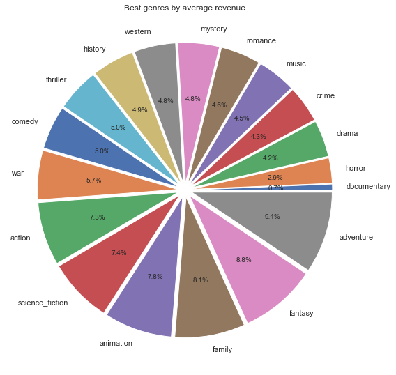

```python
revenues_values = []
genres_labels= []
fig = plt.figure(figsize=(7,7))
ax = fig.add_axes([0,0,1,1])
ax.axis('equal')
for genre in genresDictionary:
    mean_rev = genresDictionary[genre].revenue.mean()
    if mean_rev==0 or math.isnan(mean_rev):
        continue

    genres_labels.append(genre[:genre.find("genre")-1])
    revenues_values.append(mean_rev)

revenues_values, genres_labels = (list(t) for t in zip(*sorted(zip( revenues_values,genres_labels))))
explode = np.full(shape=len(revenues_values),fill_value=0.05)
ax.pie(revenues_values, labels = genres_labels, autopct='%.1f%%', explode = explode)

ax.set_title('Pie chart')
plt.title("Best genres by average revenue")
plt.show()
```

This pie chart here shows a decorrelation between it and the previous pie chart, while science fiction is the most popular, it is not by default the most earning.

Horror movies as well generally earn more than TV movies, which could be simply explained that again, no one watches a TV movie in theatre, because they are on TV.

Most genres are generally out of place an unalligned when comparing their revenue to popularity, generally showing that movies may not earn more, but they can be appreciated for what they are later on.

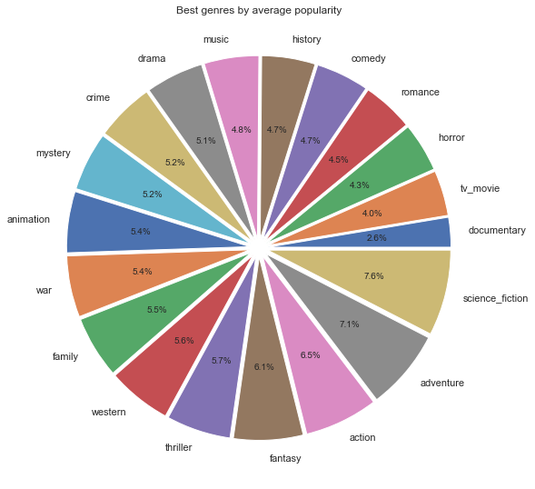

```python
popularity_values = []
genres_labels= []
fig = plt.figure(figsize=(7,7))
ax = fig.add_axes([0,0,1,1])
ax.axis('equal')
for genre in genresDictionary:
    mean_rev = genresDictionary[genre].popularity.mean()
    if mean_rev==0 or math.isnan(mean_rev):
        continue

    genres_labels.append(genre[:genre.find("genre")-1])
    popularity_values.append(mean_rev)

popularity_values, genres_labels = (list(t) for t in zip(*sorted(zip( popularity_values,genres_labels))))
explode = np.full(shape=len(popularity_values),fill_value=0.05)
ax.pie(popularity_values, labels = genres_labels, autopct='%.1f%%', explode = explode)

ax.set_title('Pie chart')
plt.title("Best genres by average popularity")
plt.show()
```

The next two charts tell an interesting story, as documentary is still getting low score on vote counts, meaning that not many vote for documentaries.

However in the next chart we find that while most gernes are generally equal in average votes, the highest one by far are documentaries, this indicates that while very little of the documentaries receive any vote at all, those votes are always highly appreciative, and it shows that whoever is watching documentaries is always the type that appreciates any quality provided knowledge

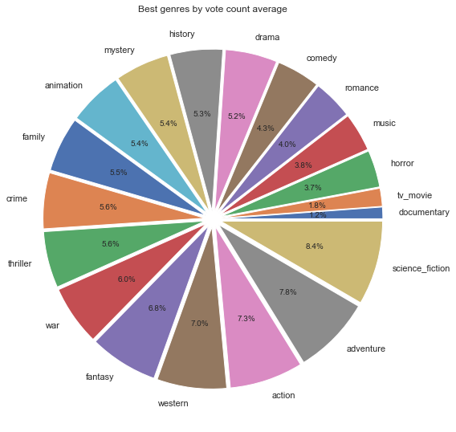

```python
vote_count_values = []
genres_labels= []
fig = plt.figure(figsize=(7,7))
ax = fig.add_axes([0,0,1,1])
ax.axis('equal')
for genre in genresDictionary:
    mean_rev = genresDictionary[genre].vote_count.mean()
    if mean_rev==0 or math.isnan(mean_rev):
        continue

    genres_labels.append(genre[:genre.find("genre")-1])
    vote_count_values.append(mean_rev)

vote_count_values, genres_labels = (list(t) for t in zip(*sorted(zip( vote_count_values,genres_labels))))
explode = np.full(shape=len(vote_count_values),fill_value=0.05)
ax.pie(vote_count_values, labels = genres_labels, autopct='%.1f%%', explode = explode)

ax.set_title('Pie chart')
plt.title("Best genres by vote count average")
plt.show()
```

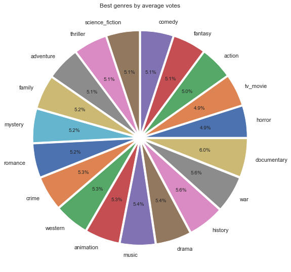

```python
vote_average_values = []
genres_labels= []
fig = plt.figure(figsize=(7,7))
ax = fig.add_axes([0,0,1,1])
ax.axis('equal')
for genre in genresDictionary:
    mean_rev = genresDictionary[genre].vote_average.mean()
    if mean_rev==0 or math.isnan(mean_rev):
        continue

    genres_labels.append(genre[:genre.find("genre")-1])
    vote_average_values.append(mean_rev)

vote_average_values, genres_labels = (list(t) for t in zip(*sorted(zip( vote_average_values,genres_labels))))
explode = np.full(shape=len(vote_average_values),fill_value=0.05)
ax.pie(vote_average_values, labels = genres_labels, autopct='%.1f%%', explode = explode)

ax.set_title('Pie chart')
plt.title("Best genres by average votes")
plt.show()
```

**While the previous charts indicate audience reception. It does not indicate any number, how many of each genre is made, and therefore which ones are more preferred by producers companies. The following chart tries to find the answer to that**

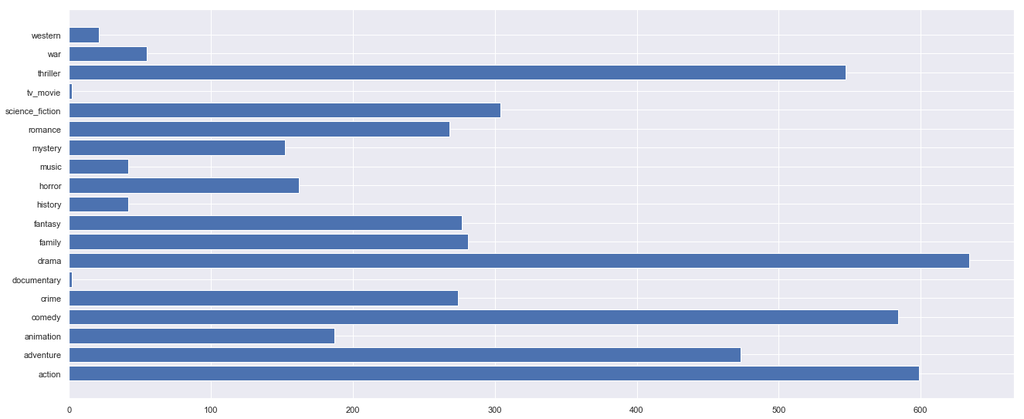

```python
fig = plt.figure(figsize=(17,7))
genres_labels = []
genre_counts = []
ax = fig.add_axes([0,0,1,1])
for genre in genresDictionary:
    count = genresDictionary[genre].vote_average.count()
    if count==0 or math.isnan(count):
        continue

    genres_labels.append(genre[:genre.find("genre")-1])
    genre_counts.append(count)

ax.barh(genres_labels,genre_counts)
plt.show()
```

## Conclusions

**For question one,** I am able to conclude that solo directors are usually more successful that cooporating directors, the biggest limitation was the imbalance in data as I could not make a clear case since most movie are directed by solos, which doesn't allow for a complete and definite picture. This however also implies that directors prefer to work solo as it is more practical to have one creative mind than many opossing ones.

## Submitting your Project

> Before you submit your project, you need to create a .html or .pdf version of this notebook in the workspace here. To do that, run the code cell below. If it worked correctly, you should get a return code of 0, and you should see the generated .html file in the workspace directory (click on the orange Jupyter icon in the upper left).

> Alternatively, you can download this report as .html via the **File** > **Download as** submenu, and then manually upload it into the workspace directory by clicking on the orange Jupyter icon in the upper left, then using the Upload button.

> Once you've done this, you can submit your project by clicking on the "Submit Project" button in the lower right here. This will create and submit a zip file with this .ipynb doc and the .html or .pdf version you created. Congratulations!

```python
from subprocess import call
call(['python', '-m', 'nbconvert', 'Investigate_a_Dataset.ipynb'])
```

```
0
```